# Survival Analysis

M. E. Perez

March 17, 2016

# Introduction to Survival Analysis

### Time to event data

In many clinical studies, the variable of interest is the time until something happens: *Time of survival of a patient participating in a new drug study.* Time from vaccination till a child suffers a rotavirus positive diarrhea. *Lifetime of an electronic component. All these are examples of time to event data or survival data.

### Survival function and hazard function

For a time to event random variable T , the survival function is defined as:

S(t)=P(T >t)=1−F(t)

Where F is the distribution function of T (F(t) = P(T ≤ t)). Then, the survival function is the probability that the time to the event is greater than t. Another important function is the hazard function or force of mortality h(t), which measures the (infinitesimal) risk of dying within a short interval of time t, given that the subject is alive at time t.

### Censoring

Sometimes, it is not possible to get information about all the participants in a survival study *Loss to follow up: the patient stop attending follow up meetings (moved to other city, etc.)* Dropout: The effects of a therapy are so bad that the treatment has to be stopped. *Termination of the study: (for studies with pre-determined stop dates). Death due to other causes.

When some of this situations happens, we say that our data is censored. There are several types of censoring, but we will concentrate on right censoring.

The main assumption made to deal with this situation is that, conditional on the values of any explanatory variable, the prognosis for any individual who has survived to a certain time t should no be affected if the individual is censored at t. In other words, survival condition and reason of loss are independent.

Also, it can be seen that in this context the time origin need not to be (and usually is not) the same calendar time for each individual.

### Kaplan-Meier estimator for the survival function

pˆi= (1−di/Si-1) = (1−di/Si+di+li )

The li subjects censored at time ti do not contribute to the estimation of the survival function at time > ti . However, these subjects do contribute to the estimation of the survival function at time ≤ ti .

## Example

For this example, we will use the `Melanoma` dataset in package `MASS`, collected by K. T. Drzewiecki and reproduced in P. K. Andersen, O. Borgan, R. D. Gill and N. Keiding (1993) Statistical Models based on Counting Processes. Springer. This data frame contains on 205 patients in Denmark with malignant melanoma

```r
library(MASS)
attach(Melanoma)
names(Melanoma)
```

```
## [1] "time"      "status"    "sex"       "age"       "year"      "thickness"
## [7] "ulcer"
```

The variable `status` is an indicator of the patient’s status by the end of the study: 1 means “dead from malignant melanoma”, 2 means “alive on January 1, 1978”, and 3 means “dead from other causes. The variable `time` is the observation time in days,`ulcer` indicates (1 for present and 2 for absent) whether the tumor was ulcerated, `thickness` is the thickness in 1/100 mm, `age` is the age of the patient in years and `sex` contains the gender of the patient (0 for women and 1 for men).

Only `status=1` will be considered an event (2 and 3 are considered censorings). We will then construct a survival object using `time` and `status`.

```r
library(survival)
surv.melanom <- Surv(time,status==1)
surv.melanom
```

```
##   [1]   10+   30+   35+   99+  185   204   210   232+  232   279   295
##  [12]  355+  386   426   469   493+  529   621   629   659   667   718
##  [23]  752   779   793   817   826+  833   858   869   872   967   977
##  [34]  982  1041  1055  1062  1075  1156  1228  1252  1271  1312  1427+
##  [45] 1435  1499+ 1506  1508+ 1510+ 1512+ 1516  1525+ 1542+ 1548  1557+
##  [56] 1560  1563+ 1584  1605+ 1621  1627+ 1634+ 1641+ 1641+ 1648+ 1652+
##  [67] 1654+ 1654+ 1667  1678+ 1685+ 1690  1710+ 1710+ 1726  1745+ 1762+
##  [78] 1779+ 1787+ 1787+ 1793+ 1804+ 1812+ 1836+ 1839+ 1839+ 1854+ 1856+
##  [89] 1860+ 1864+ 1899+ 1914+ 1919+ 1920+ 1927+ 1933  1942+ 1955+ 1956+
## [100] 1958+ 1963+ 1970+ 2005+ 2007+ 2011+ 2024+ 2028+ 2038+ 2056+ 2059+
## [111] 2061  2062  2075+ 2085+ 2102+ 2103  2104+ 2108  2112+ 2150+ 2156+
## [122] 2165+ 2209+ 2227+ 2227+ 2256  2264+ 2339+ 2361+ 2387+ 2388  2403+
## [133] 2426+ 2426+ 2431+ 2460+ 2467  2492+ 2493+ 2521+ 2542+ 2559+ 2565
## [144] 2570+ 2660+ 2666+ 2676+ 2738+ 2782  2787+ 2984+ 3032+ 3040+ 3042
## [155] 3067+ 3079+ 3101+ 3144+ 3152+ 3154+ 3180+ 3182+ 3185+ 3199+ 3228+
## [166] 3229+ 3278+ 3297+ 3328+ 3330+ 3338  3383+ 3384+ 3385+ 3388+ 3402+
## [177] 3441+ 3458+ 3459+ 3459+ 3476+ 3523+ 3667+ 3695+ 3695+ 3776+ 3776+
## [188] 3830+ 3856+ 3872+ 3909+ 3968+ 4001+ 4103+ 4119+ 4124+ 4207+ 4310+
## [199] 4390+ 4479+ 4492+ 4668+ 4688+ 4926+ 5565+
```

The plus signs indicates censored observations.

Using this survival object, we will fit a Kaplan-Meier survival curve with command `survfit`.

```r
melanoma.km <- survfit(surv.melanom~1)
summary(melanoma.km)
```

```
## Call: survfit(formula = surv.melanom ~ 1)
##
##  time n.risk n.event survival std.err lower 95% CI upper 95% CI
##   185    201       1    0.995 0.00496        0.985        1.000
##   204    200       1    0.990 0.00700        0.976        1.000
##   210    199       1    0.985 0.00855        0.968        1.000
##   232    198       1    0.980 0.00985        0.961        1.000
##   279    196       1    0.975 0.01100        0.954        0.997
##   295    195       1    0.970 0.01202        0.947        0.994
##   386    193       1    0.965 0.01297        0.940        0.991
##   426    192       1    0.960 0.01384        0.933        0.988
##   469    191       1    0.955 0.01465        0.927        0.984
##   529    189       1    0.950 0.01542        0.920        0.981
##   621    188       1    0.945 0.01615        0.914        0.977
##   629    187       1    0.940 0.01683        0.907        0.973
```

[output cut: 45 more lines]

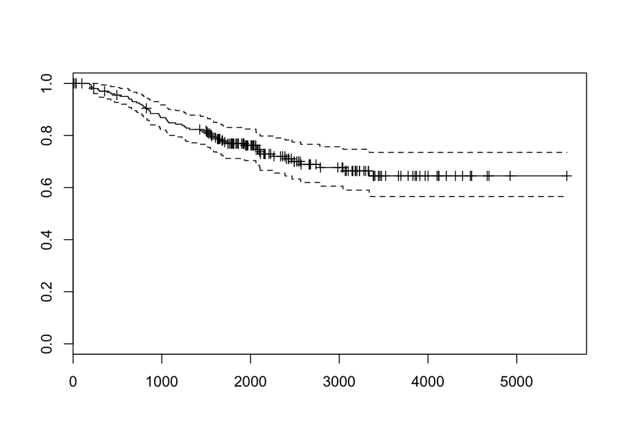

```r
plot(melanoma.km)
```

By default, `plot` adds to the graph the confidence intervals. Note that this intervals are not symmetrical, because they were calculated in the log scale and then transformed.

It is useful to plot two or more survival curves in the same graph for direct comparison. For example, we can fit survival curves by sex.

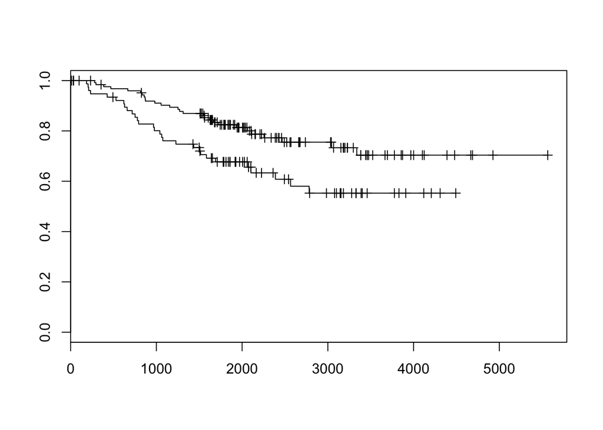

```r
melanoma.sex=survfit(surv.melanom~sex)
plot(melanoma.sex)
```

Note that when plotting more than one survival curve, the confidence intervals are not displayed (in order to avoid confusing graphs). Nevertheless, we can plot the confidence intervals using `conf.int=T`.

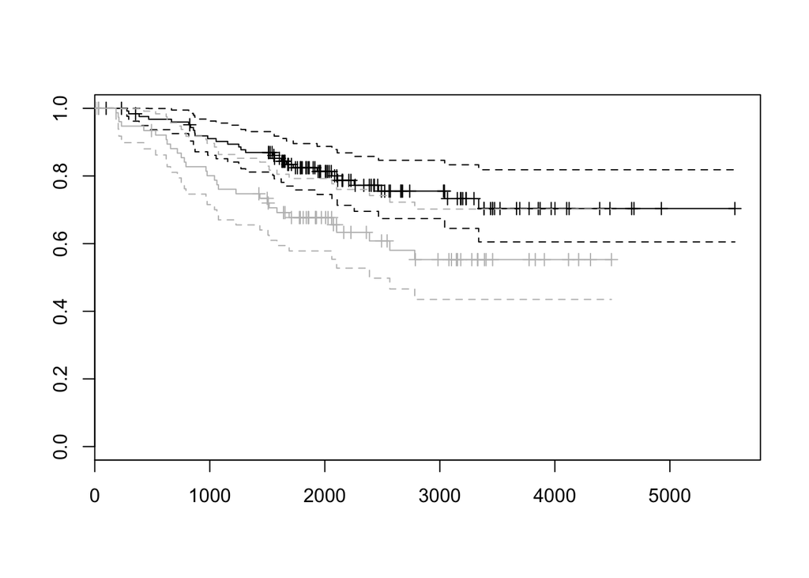

```r
plot(melanoma.sex,conf.int=T, col=c("black","gray"))
```

It can be seen that the curve for women is over the curve for men, indicating higher survival. Nevertheless, confidence intervals are overimposed throughtout the whole graph.

For comparing this two curves, we can use the command `survdiff`

```r
survdiff(surv.melanom~sex)
```

```
## Call:
## survdiff(formula = surv.melanom ~ sex)
##
##         N Observed Expected (O-E)^2/E (O-E)^2/V
## sex=0 126       28     37.1      2.25      6.47
## sex=1  79       29     19.9      4.21      6.47
##
##  Chisq= 6.5  on 1 degrees of freedom, p= 0.011
```

The difference of survival between men and women seems to be significant.